# Lab8

Marlee Galloway

11/9/2020

# 1. Use NGPhylogeny.fr to analysis the set of rRNA sequence provided. Describe the methods and put the .png file from your analysis into your Lab 8 .Rmd file

## Methods:

# - Downloaded the file Tree_of_Life_Core_Sequences.txt to my computer.

# - Opened link for the site: Robust Phylogenetic Analysis For The Non-Specialist.

# - Uploaded the DNA sequences from the Tree_of_Life_Core_Sequences.txt file to the site.

# - Submitted the file to start analysis.

# - Saved the tree as both a .png file for upload to .Rmd, and as a newick file.

# Load the image:

[figure not shown]

Output Tree

# 2. Align and do phylogenetic analysis off the sequences in CIPRES using MAFFT and FastTreeMP. Here is my step by step tutorial on using CIPRES. You will need to click on Parameter Set and Save even if you don’t change the parameters. Download the fastree_result.tre to your computer.

# 3. Go through the tutorial on Visualizing and Annotating Phylogenetic Trees with R+ggtree adding the steps to your .Rmd file.

# -Download Bioconductor:

```r
if (!requireNamespace("BiocManager", quietly = TRUE))
    install.packages("BiocManager")

BiocManager::install("ggtree")
```

# -Load packages:

```r
library(tidyverse)
library(ggtree)
library(treeio)
```

```r
library(ggimage)
```

# Tree Import

## -Basic trees:

```r
tree <- read.tree("data/tree_newick.nwk")
tree
```

```
##
## Phylogenetic tree with 13 tips and 12 internal nodes.
##
## Tip labels:
##   A, B, C, D, E, F, ...
##
## Rooted; includes branch lengths.
```

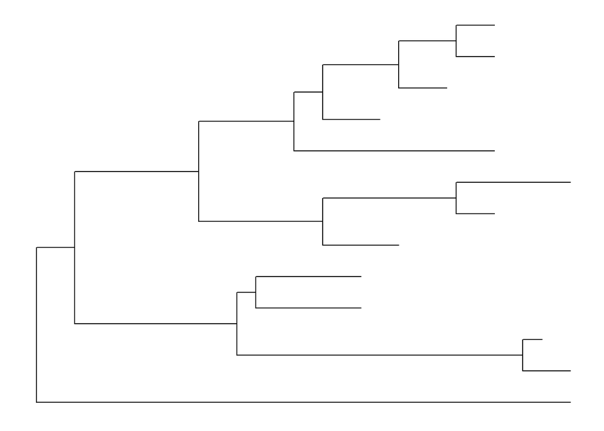

```r
# build a ggplot with a geom_tree
ggplot(tree) + geom_tree() + theme_tree()
```

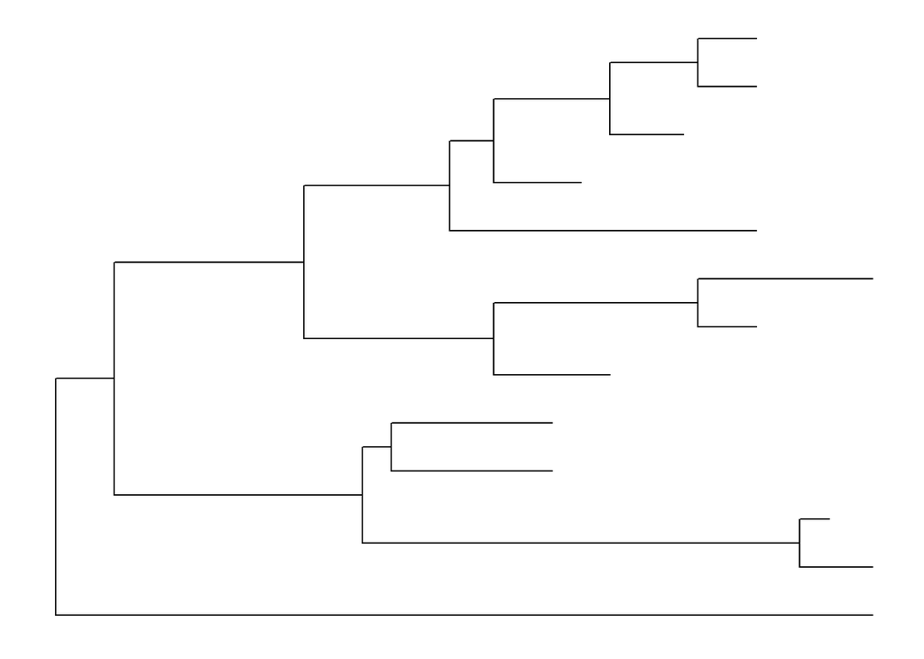

```r
# This is convenient shorthand
ggtree(tree)
```

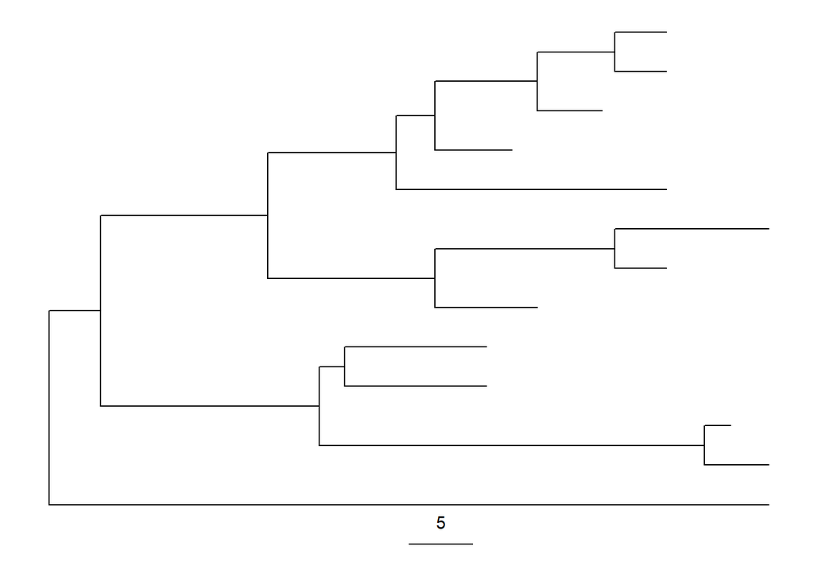

```r
# add a scale
ggtree(tree) + geom_treescale()
```

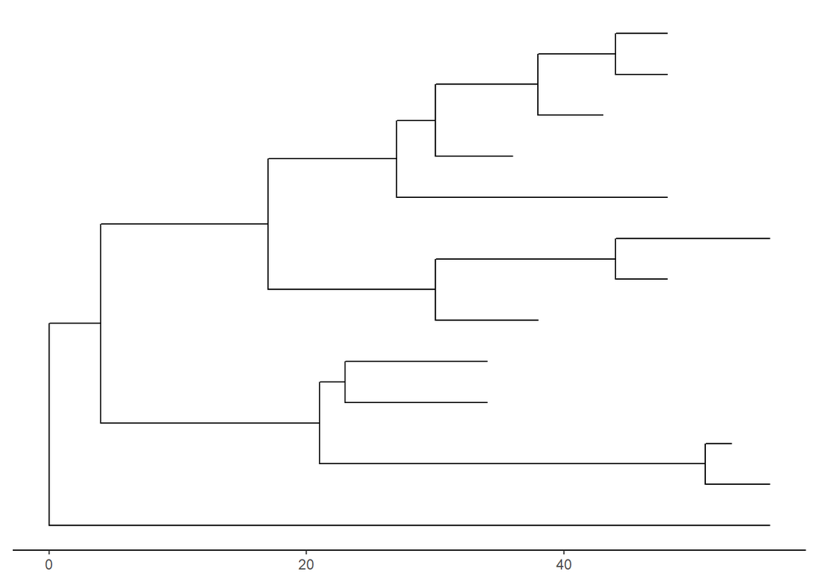

```r
# or add the entire scale to the x axis with theme_tree2()
ggtree(tree) + theme_tree2()
```

# For cladogram:

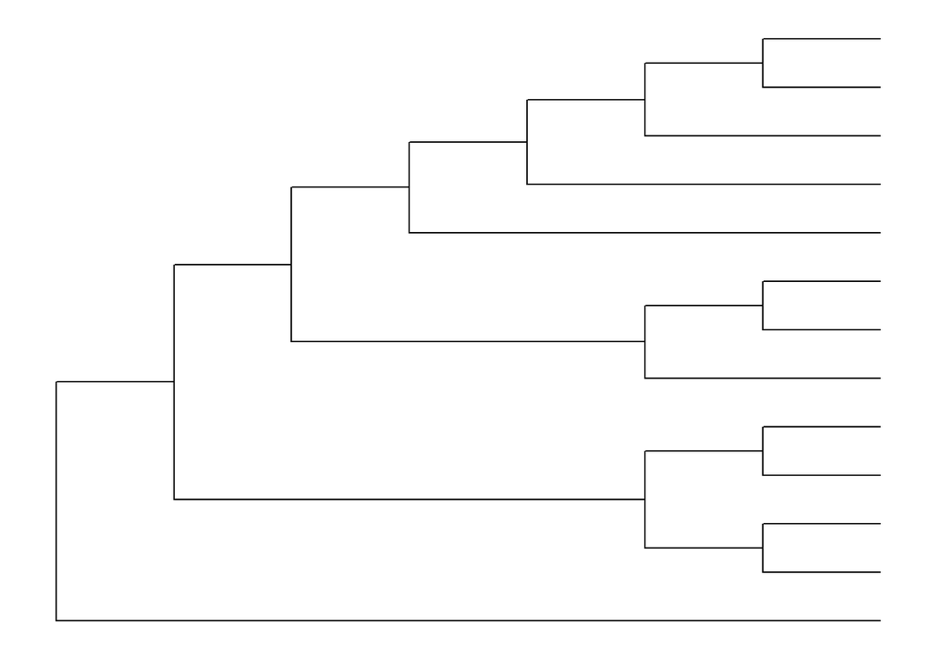

```r
ggtree(tree, branch.length="none")
```

# To change aesthetics:

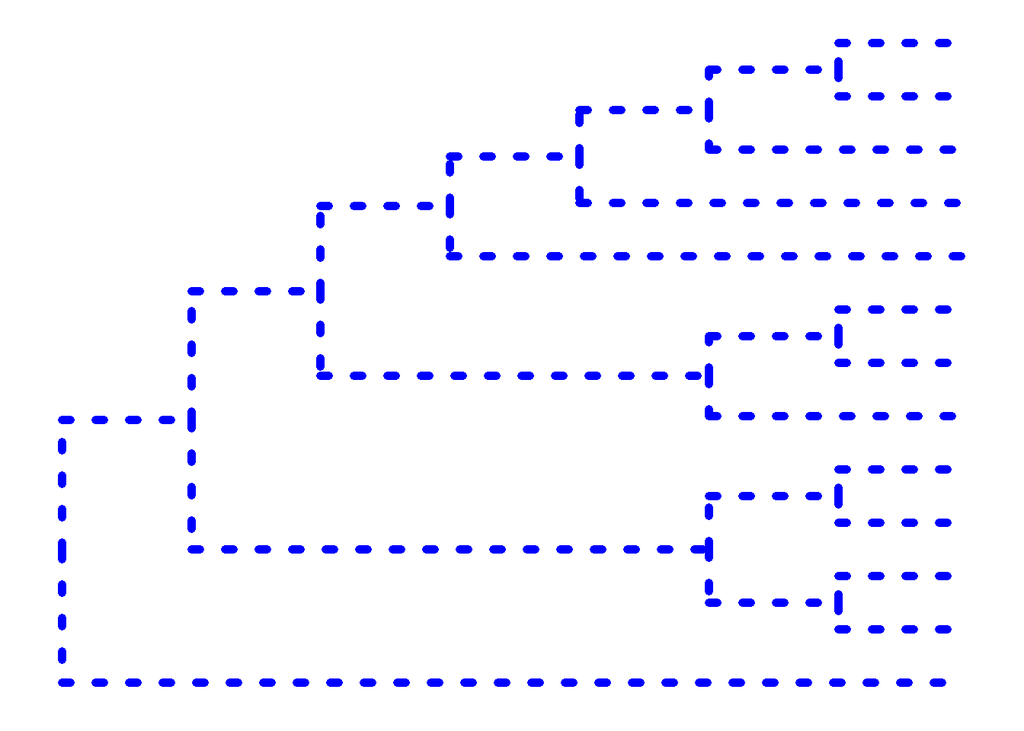

```r
ggtree(tree, branch.length="none", color="blue", size=2, linetype=3)
```

# Exercise 1:

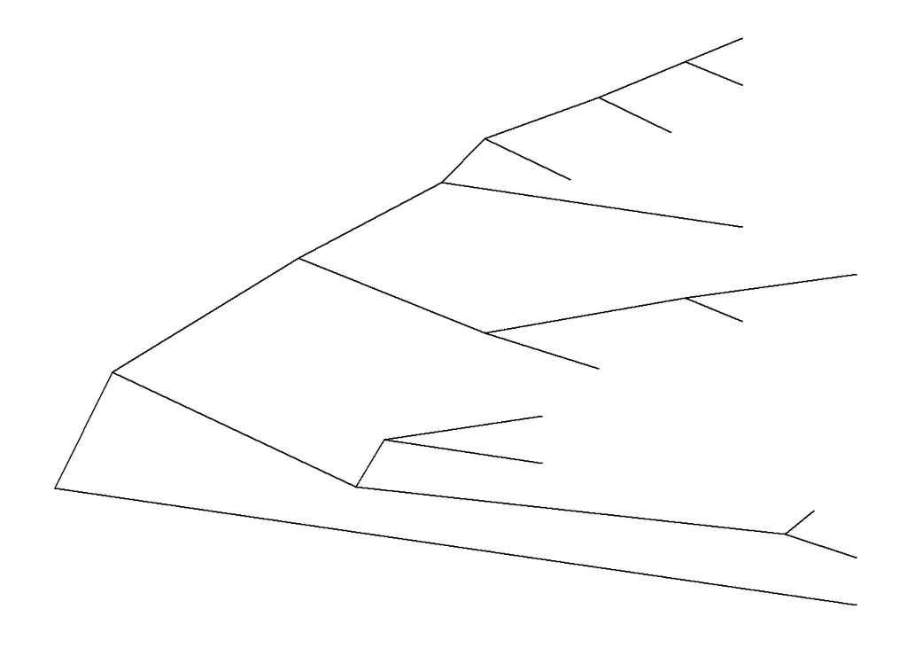

```r
ggtree(tree, layout = 'slanted')
```

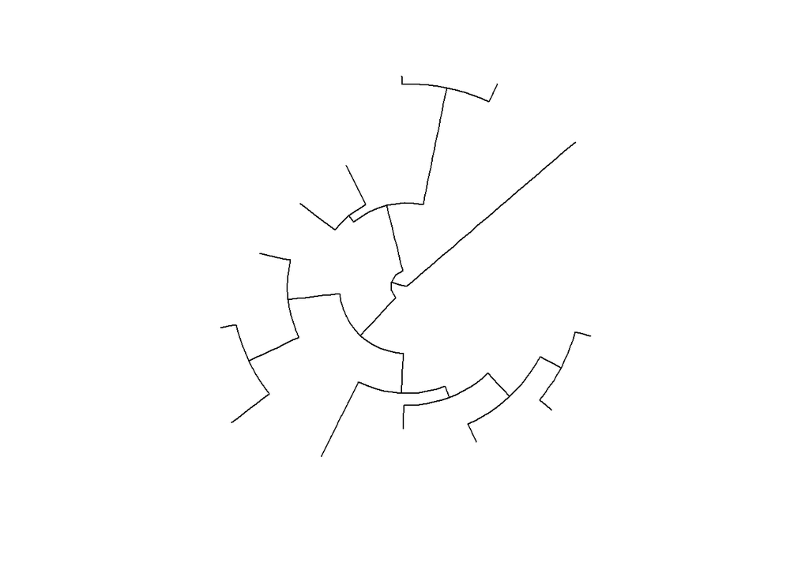

```r
ggtree(tree, layout = 'circular')
```

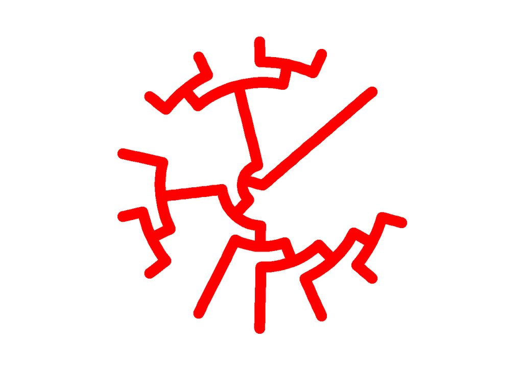

```r
ggtree(tree, branch.length = "none", layout = 'circular', color = "red", size = 5)
```

# Other tree geoms:

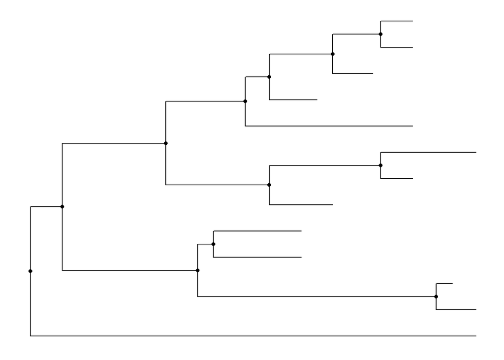

```r
# create the basic plot
p <- ggtree(tree)
# add node points
p + geom_nodepoint()
```

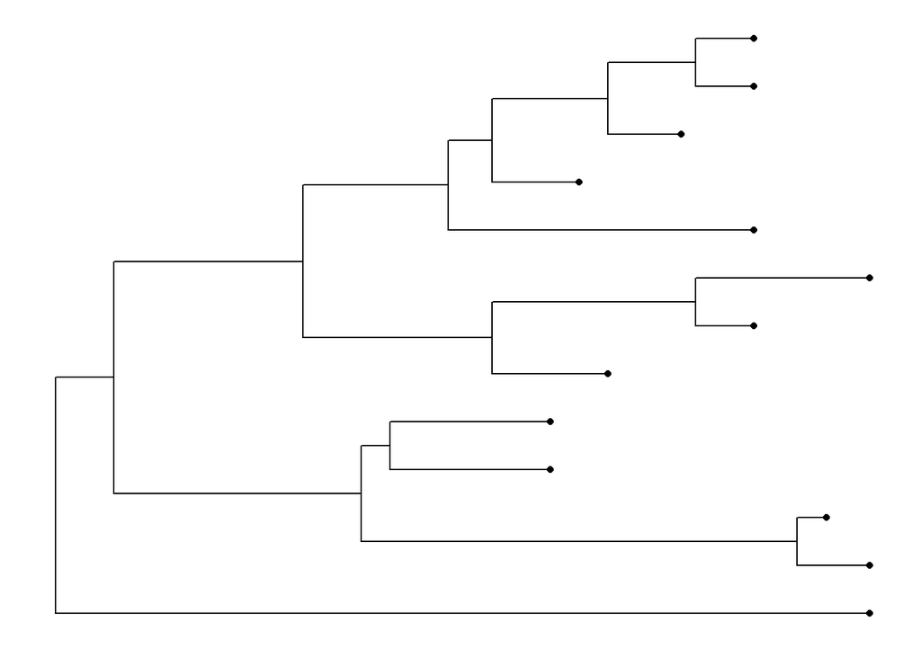

```r
# add tip points
p + geom_tippoint()
```

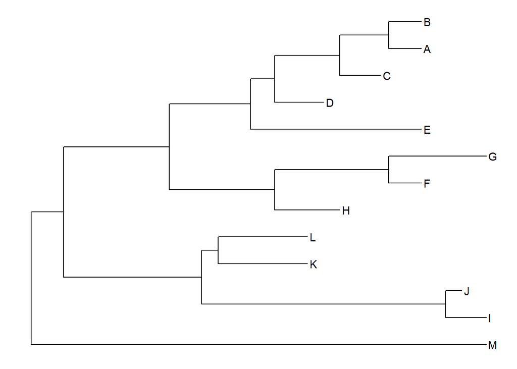

```r
# Label the tips
p + geom_tiplab()
```

# Exercise 2:

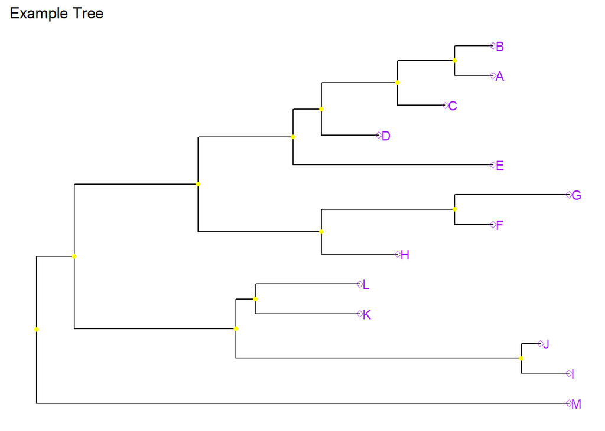

```r
ggtree(tree) + geom_tippoint(color = "purple", pch = 5) + geom_tiplab(color = "purple") + geom_nodepoint(alpha = 1, color = "yellow") + ggtitle("Example Tree")
```

# -Internal node number:

## Use geom_text

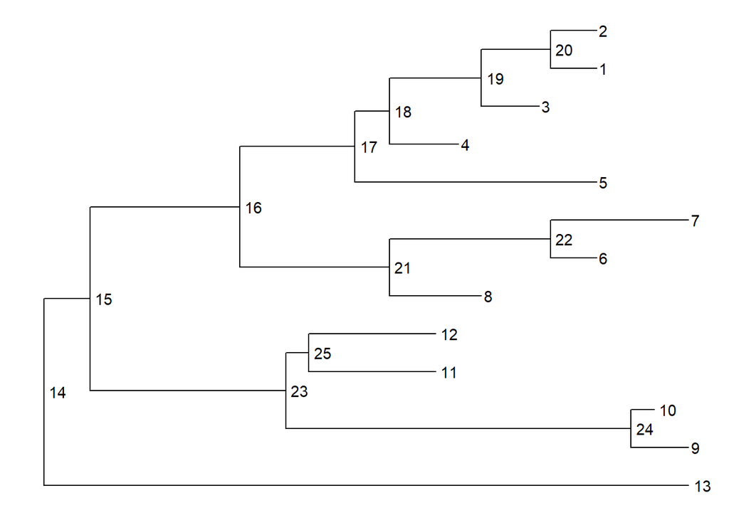

```r
ggtree(tree) + geom_text(aes(label=node), hjust=-.3)
```

## Use MRCA, re-create plot to choose taxa:

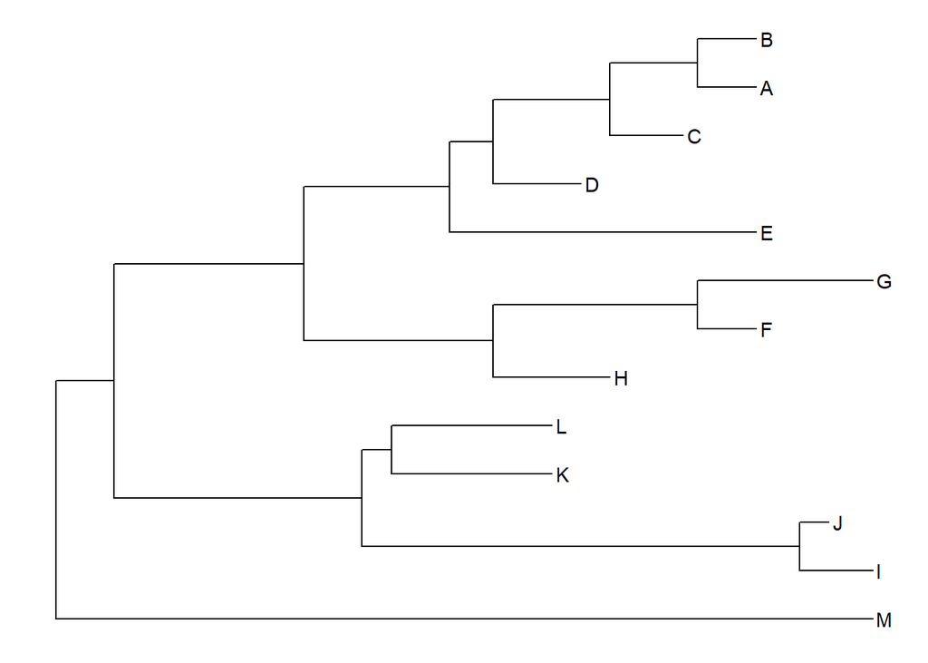

```r
ggtree(tree) + geom_tiplab()
```

```r
MRCA(tree, c("C", "E"))
```

```
## [1] 17
```

```r
MRCA(tree, c("G", "H"))
```

```
## [1] 21
```

# Labeling clades

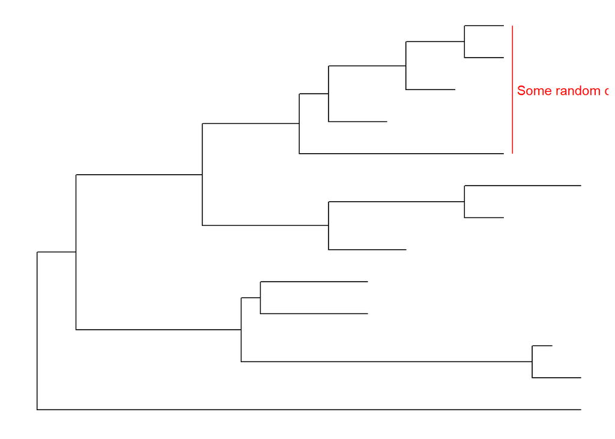

```r
ggtree(tree) +
  geom_cladelabel(node=17, label="Some random clade", color="red")
```

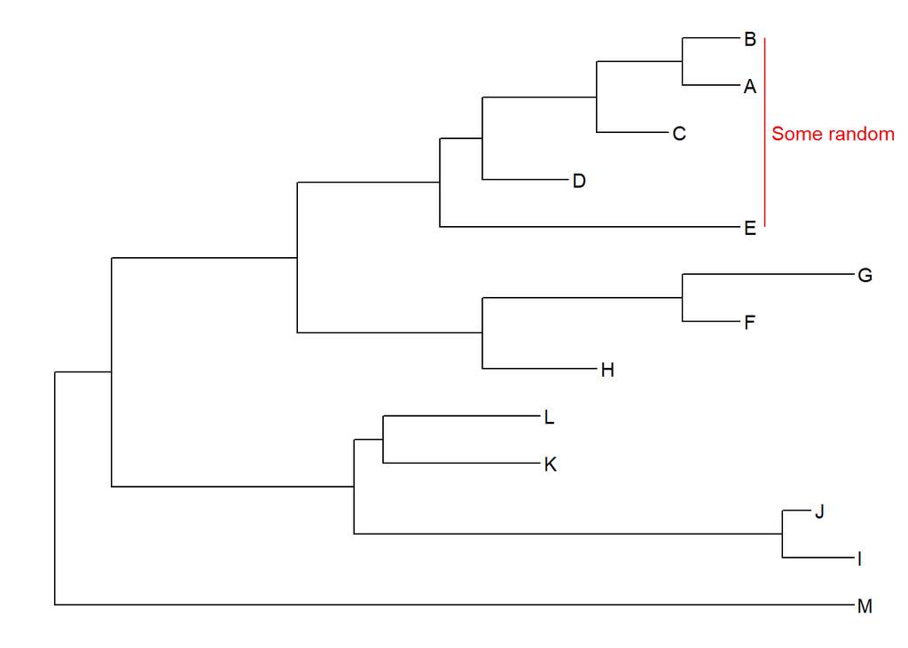

```r
ggtree(tree) +
  geom_tiplab() +
  geom_cladelabel(node=17, label="Some random clade",
                  color="red2", offset=.8)
```

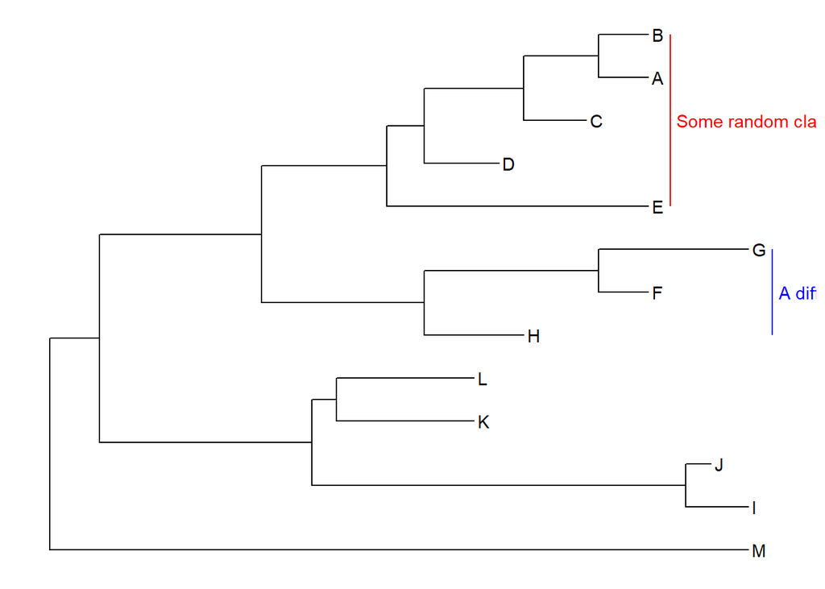

```r
ggtree(tree) +
  geom_tiplab() +
  geom_cladelabel(node=17, label="Some random clade",
                  color="red2", offset=.8) +
  geom_cladelabel(node=21, label="A different clade",
                  color="blue", offset=.8)
```

# To fix the labels:

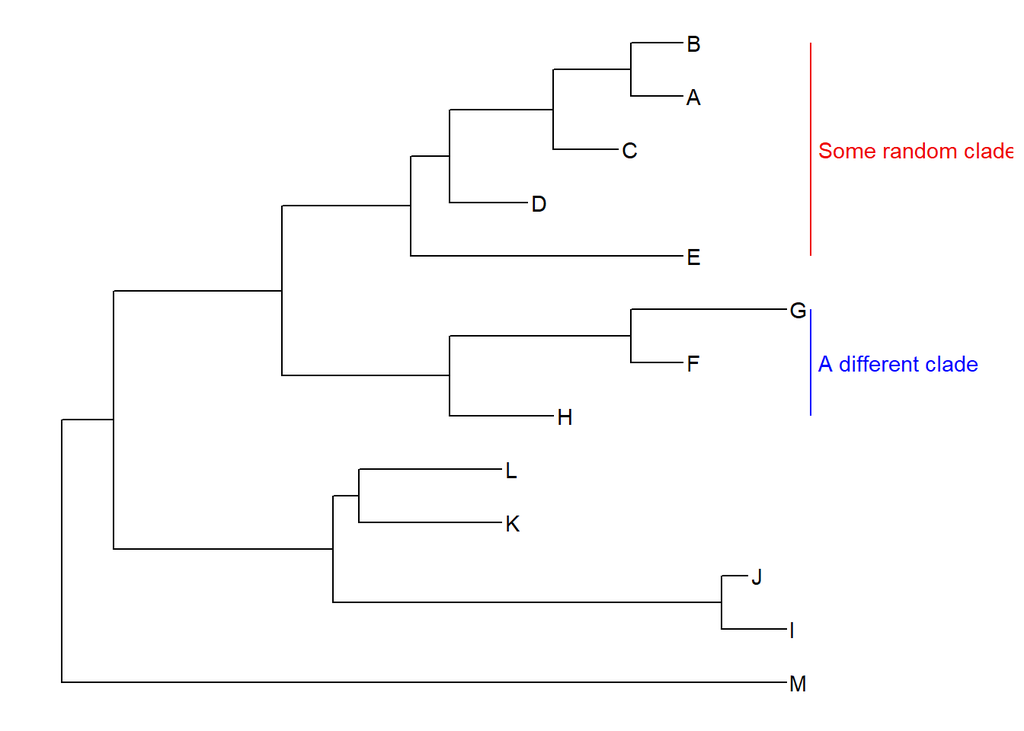

```r
ggtree(tree) +
  geom_tiplab() +
  geom_cladelabel(node=17, label="Some random clade",
                  color="red2", offset=.8, align=TRUE) +
  geom_cladelabel(node=21, label="A different clade",
                  color="blue", offset=.8, align=TRUE) +
  theme_tree2() +
  xlim(0, 70) +
  theme_tree()
```

# To highlight the entire clade:

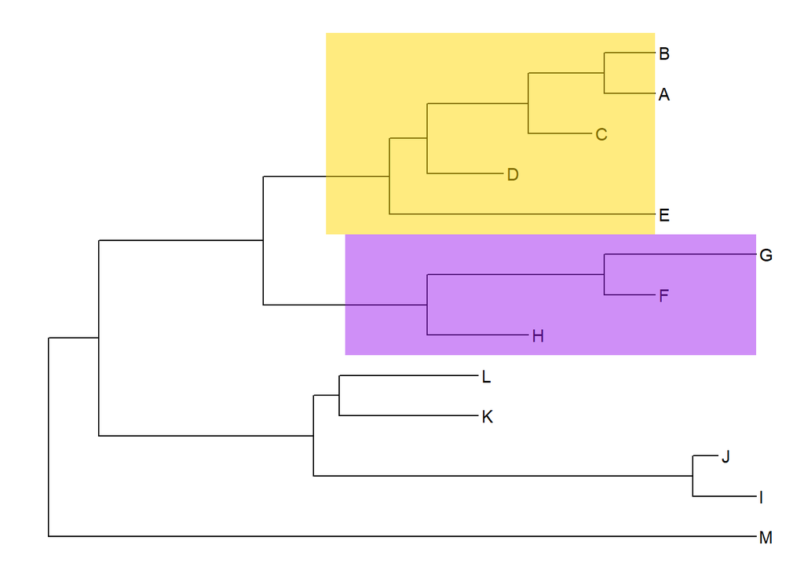

```r
ggtree(tree) +
  geom_tiplab() +
  geom_hilight(node=17, fill="gold") +
  geom_hilight(node=21, fill="purple")
```

## Connecting Taxa

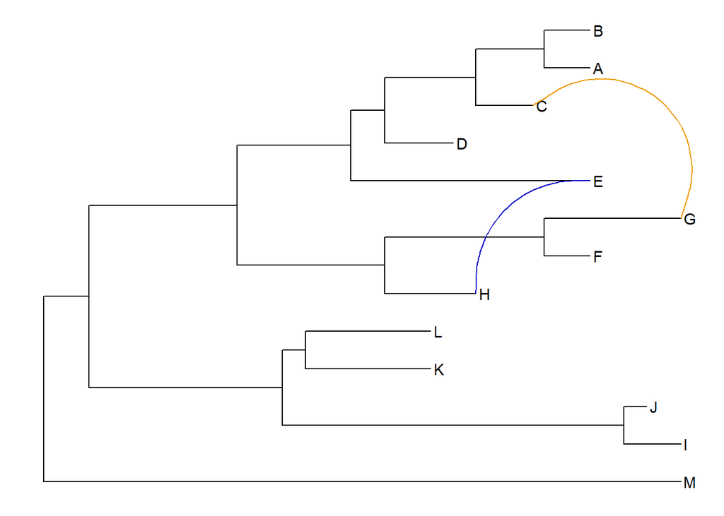

```r
ggtree(tree) +
  geom_tiplab() +
  geom_taxalink("E", "H", color="blue3") +
  geom_taxalink("C", "G", color="orange2", curvature=-.9)
```

# Exercise 3:

## Find what the MRCA is for B+C and L+J, draw tree, add tip labels, highlight clades with seperate colors,

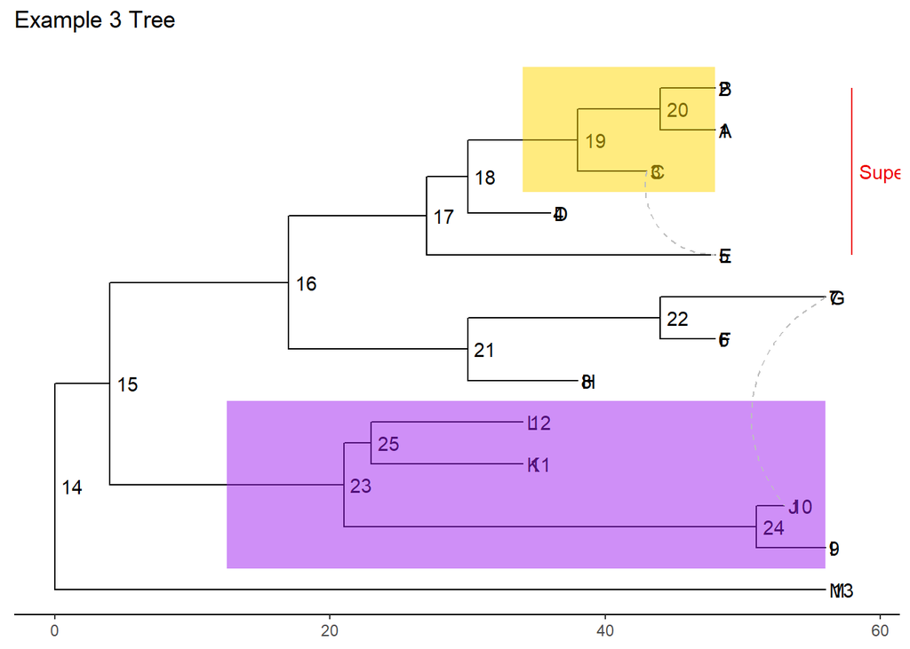

```r
ggtree(tree) + geom_text(aes(label=node), hjust=-.3) +
  geom_tiplab() +
  geom_highlight(node=19, fill="gold") +
  geom_highlight(node=23, fill="purple") +
   geom_cladelabel(node=17, label="Superclade 17",
                  color="red2", offset=.8, align=TRUE) +
  geom_taxalink("C","E", color = "grey", linetype = 2) +
  geom_taxalink("G","J", color = "grey", linetype = 2) +
  theme_tree2() +
  ggtitle("Example 3 Tree")
```

# Advanced tree annotation

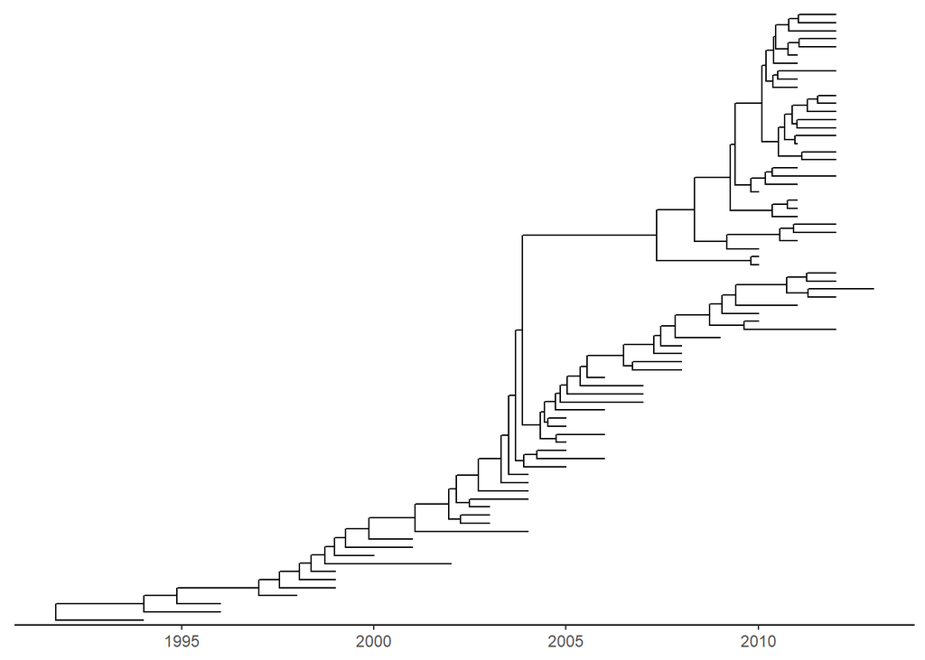

```r
# Read the data
tree <- read.beast("data/flu_tree_beast.tree")
# supply a most recent sampling date so you get the dates
# and add a scale bar
ggtree(tree, mrsd="2013-01-01") +
  theme_tree2()
```

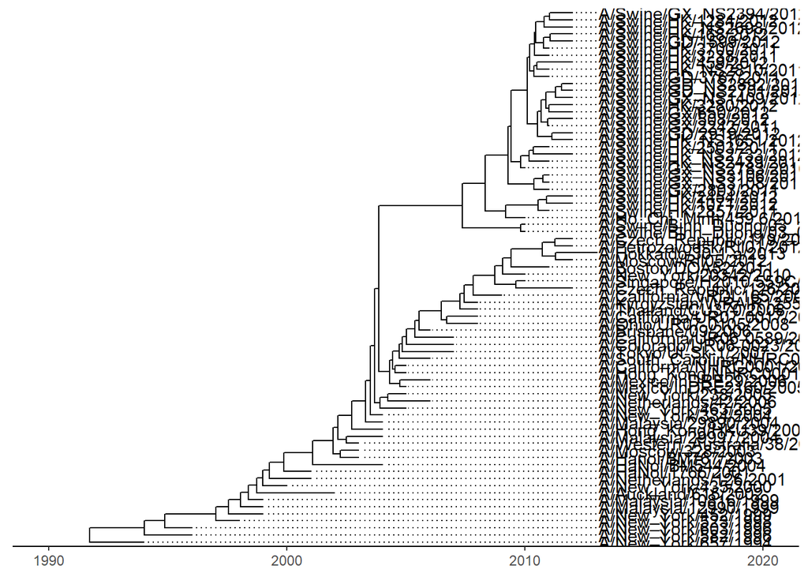

```r
# Finally, add tip labels and adjust axis
ggtree(tree, mrsd="2013-01-01") +
  theme_tree2() +
  geom_tiplab(align=TRUE, linesize=.5) +
  xlim(1990, 2020)
```

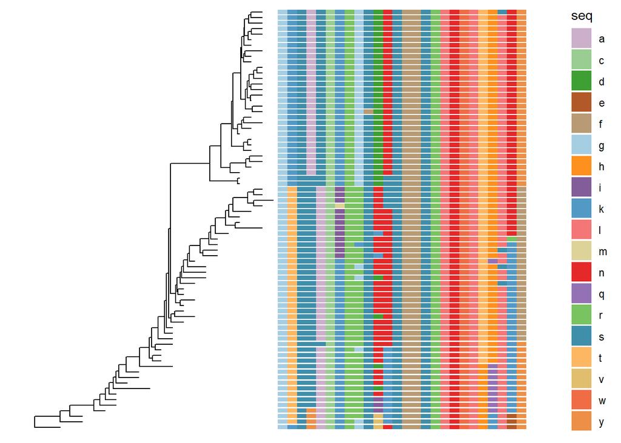

```r
msaplot(p=ggtree(tree), fasta="data/flu_aasequence.fasta", window=c(150, 175))
```

## Bonus:

# Generating multiple trees at once:

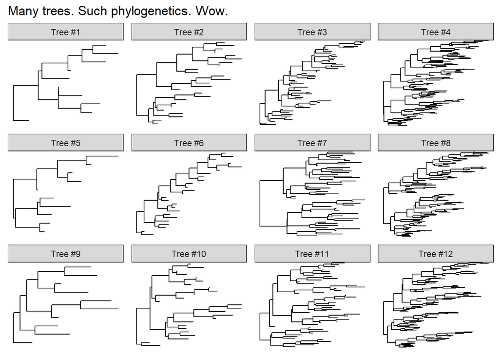

```r
set.seed(42)
trees <- lapply(rep(c(10, 25, 50, 100), 3), rtree)
class(trees) <- "multiPhylo"
ggtree(trees) + facet_wrap(~.id, scale="free", ncol=4) + ggtitle("Many trees. Such phylogenetics. Wow.")
```

# Plotting tree with other data:

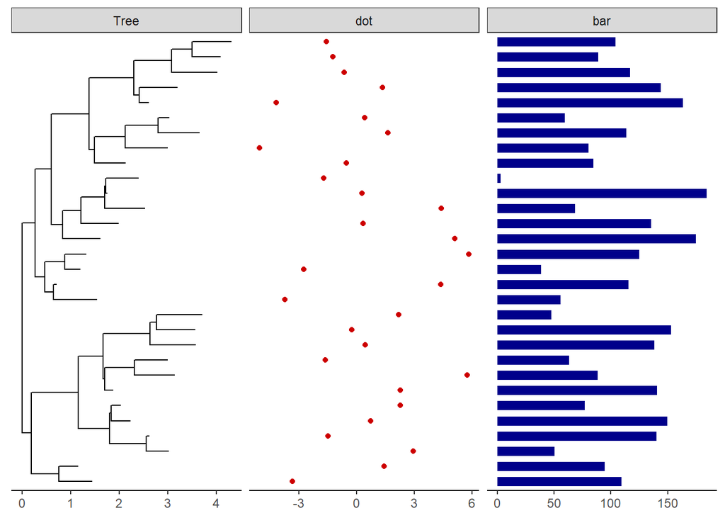

```r
# Generate a random tree with 30 tips
tree <- rtree(30)
# Make the original plot
p <- ggtree(tree)
# generate some random values for each tip label in the data
d1 <- data.frame(id=tree$tip.label, val=rnorm(30, sd=3))
# Make a second plot with the original, naming the new plot "dot",
# using the data you just created, with a point geom.
p2 <- facet_plot(p, panel="dot", data=d1, geom=geom_point, aes(x=val), color='red3')
# Make some more data with another random value.
d2 <- data.frame(id=tree$tip.label, value = abs(rnorm(30, mean=100, sd=50)))
# Now add to that second plot, this time using the new d2 data above,
# This time showing a bar segment, size 3, colored blue.
p3 <- facet_plot(p2, panel='bar', data=d2, geom=geom_segment,
           aes(x=0, xend=value, y=y, yend=y), size=3, color='blue4')
# Show all three plots with a scale
p3 + theme_tree2()
```

# Overlay organism silouhettes:

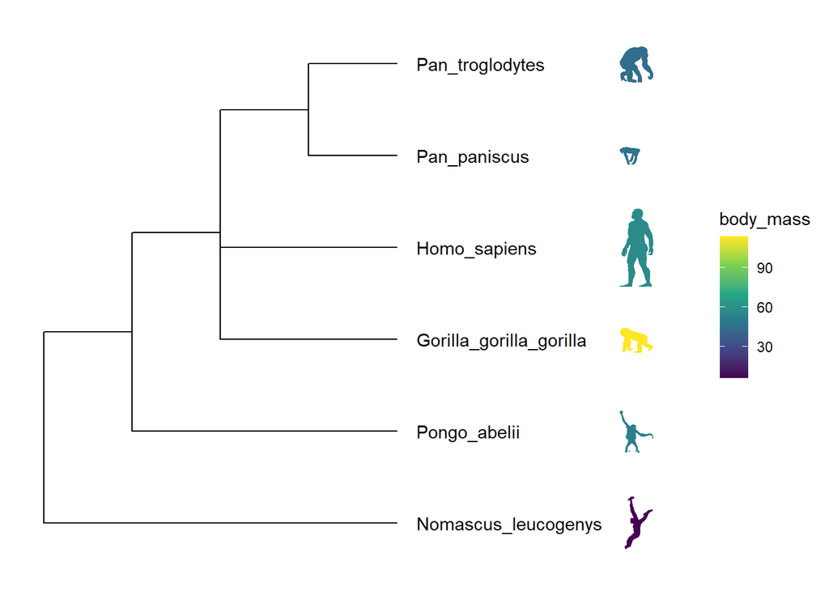

```r
# get phylopic

newick <- "((Pongo_abelii,(Gorilla_gorilla_gorilla,(Pan_paniscus,Pan_troglodytes)Pan,Homo_sapiens)Homininae)Hominidae,Nomascus_leucogenys)Hominoidea;"

tree <- read.tree(text=newick)

d <- ggimage::phylopic_uid(tree$tip.label)
d$body_mass = c(52, 114, 47, 45, 58, 6)

p <- ggtree(tree) %<+% d +
  geom_tiplab(aes(image=uid, colour=body_mass), geom="phylopic", offset=2.5) +
  geom_tiplab(aes(label=label), offset = .2) + xlim(NA, 7) +
  scale_color_viridis_c()
p
```

# 4. Upload your tree file from the FastTreeMP output on CIPRES into R using treeio. Using ggtree to make the tree images, coloring the tree according to the domains of life.

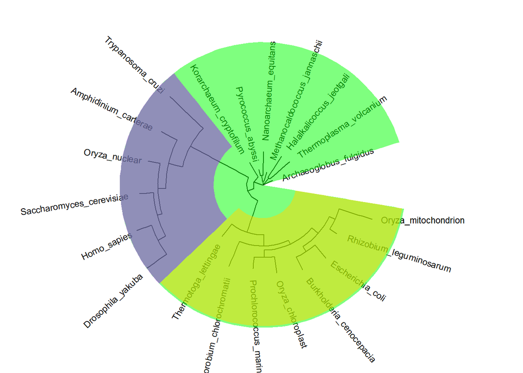

```r
tree2 <- read.tree("data/TOL_fastree_result.tre")
ggtree(tree2, layout = "circular") +
  geom_nodelab() +
  geom_tiplab(hjust=-.1, size = 3) +
  geom_highlight(node = 22, fill = "green") +
  geom_highlight(node = 25, fill = "purple") +
  geom_highlight(node = 30, fill = "gold", extend = 0.2)
```

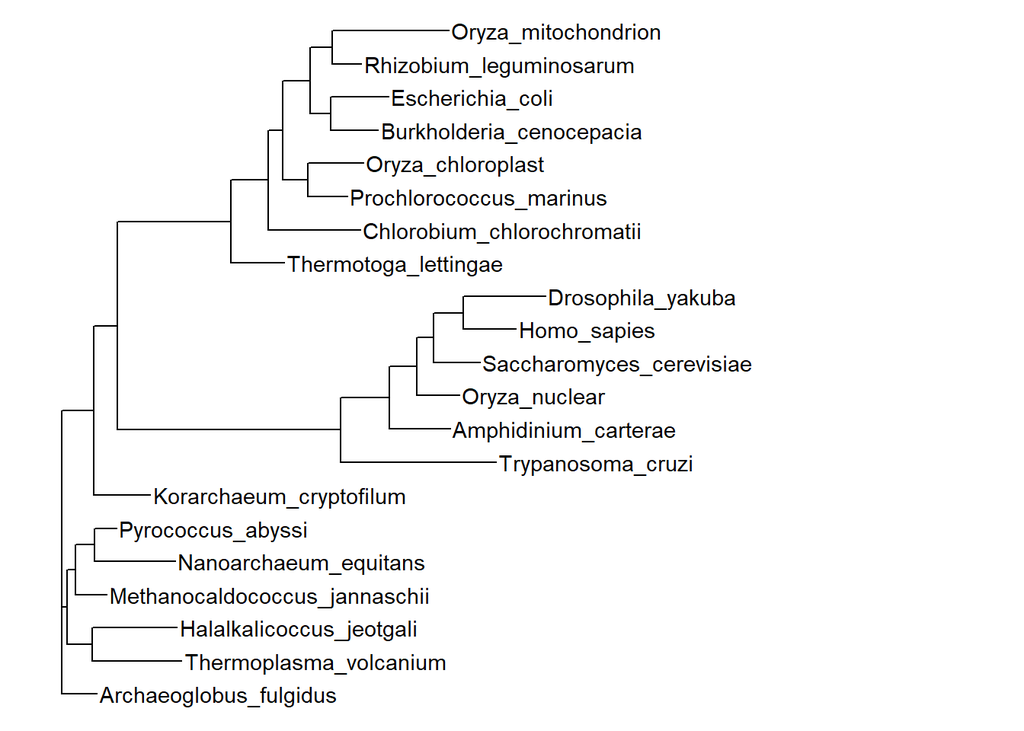

```r
ggtree(tree2) + geom_tiplab() +
  xlim(0,2)
```

```r
MRCA(tree2, c("Trypanosoma_cruzi", "Drosophila_yakuba"))
```

```
## [1] 25
```

```r
MRCA(tree2, c("Thermotoga_lettingae", "Oryza_mitochondrion"))
```

```
## [1] 30
```

```r
MRCA(tree2, c("Korarchaeum_cryptofilum", "Archaeoglobus_fulgidus"))
```

```
## [1] 22
```